# Project: Investigate a Dataset - [Medical Appointment No Shows]

## Introduction

### Dataset Description

The dataset consists of 100,000 medical appointments in Brazil, with a primary focus on determining whether patients attend their scheduled appointments or not. It also contains various characteristics related to the patients who have made these appointments. Our goal is to analyze this dataset in order to answer specific questions and identify factors that may influence attendance at these appointments. By examining the data, we aim to gain insights into the patterns and correlations that can help us better understand patient behavior and appointment attendance.

The dataset consists of several columns, each representing different variables or attributes.

PatientId ,AppointmentID, Gender ,ScheduledDay, AppointmentDay ,Age ,Neighbourhood,Scholarship ,Hipertension,Diabetes ,Alcoholism ,Handcap ,SMS_received ,No-show

1-Is there a correlation between gender and no-shows for appointments?

2-Which age group has a higher number of no-shows for appointments?

3-Is there a correlation between having a handicap and not showing up for appointments?

4- Does receiving SMS increase the chances of show-up?

```python
import pandas as pd
import numpy as np
import matplotlib.pyplot as plt
import seaborn as sns
%matplotlib inline
```

## Data Wrangling

> In this section of the report, we will cover the initial steps of the data analysis process, which include loading the data, conducting cleanliness checks, and preparing the dataset for analysis. These steps are essential to ensure that the data is reliable and suitable for further exploration.

# General Properties

```python
df = pd.read_csv('.//Database_No_show_appointments/noshowappointments-kagglev2-may-2016.csv')
df.head()
```

|  | PatientId | AppointmentID | Gender | ScheduledDay | AppointmentDay | Age | Neighbourhood | Scholarship | Hipertension | Diabetes | Alcoholism | Handcap | SMS_received | No-show |
| --- | --- | --- | --- | --- | --- | --- | --- | --- | --- | --- | --- | --- | --- | --- |
| 0 | 2.987250e+13 | 5642903 | F | 2016-04-29T18:38:08Z | 2016-04-29T00:00:00Z | 62 | JARDIM DA PENHA | 0 | 1 | 0 | 0 | 0 | 0 | No |
| 1 | 5.589978e+14 | 5642503 | M | 2016-04-29T16:08:27Z | 2016-04-29T00:00:00Z | 56 | JARDIM DA PENHA | 0 | 0 | 0 | 0 | 0 | 0 | No |
| 2 | 4.262962e+12 | 5642549 | F | 2016-04-29T16:19:04Z | 2016-04-29T00:00:00Z | 62 | MATA DA PRAIA | 0 | 0 | 0 | 0 | 0 | 0 | No |
| 3 | 8.679512e+11 | 5642828 | F | 2016-04-29T17:29:31Z | 2016-04-29T00:00:00Z | 8 | PONTAL DE CAMBURI | 0 | 0 | 0 | 0 | 0 | 0 | No |
| 4 | 8.841186e+12 | 5642494 | F | 2016-04-29T16:07:23Z | 2016-04-29T00:00:00Z | 56 | JARDIM DA PENHA | 0 | 1 | 1 | 0 | 0 | 0 | No |

```python
df.info()
```

```
<class 'pandas.core.frame.DataFrame'>
RangeIndex: 110527 entries, 0 to 110526
Data columns (total 14 columns):
 #   Column          Non-Null Count   Dtype
---  ------          --------------   -----
 0   PatientId       110527 non-null  float64
 1   AppointmentID   110527 non-null  int64
 2   Gender          110527 non-null  object
 3   ScheduledDay    110527 non-null  object
 4   AppointmentDay  110527 non-null  object
 5   Age             110527 non-null  int64
 6   Neighbourhood   110527 non-null  object
 7   Scholarship     110527 non-null  int64
 8   Hipertension    110527 non-null  int64
 9   Diabetes        110527 non-null  int64
 10  Alcoholism      110527 non-null  int64
 11  Handcap         110527 non-null  int64
 12  SMS_received    110527 non-null  int64
 13  No-show         110527 non-null  object
dtypes: float64(1), int64(8), object(5)
memory usage: 11.8+ MB
```

The info() method provides an overview of the DataFrame, including the data types of its columns. In this case, the "patientID" column is currently classified as a float, while the "ScheduledDay" and "AppointmentDay" columns are categorized as "Object" data types. However, these data types will be modified during the data-cleaning process.

```python
df.shape
```

```
(110527, 14)
```

110,527 record 14 column

```python
df.isnull().any()
```

```
PatientId         False
AppointmentID     False
Gender            False
ScheduledDay      False
AppointmentDay    False
Age               False
Neighbourhood     False
Scholarship       False
Hipertension      False
Diabetes          False
Alcoholism        False
Handcap           False
SMS_received      False
No-show           False
dtype: bool
```

The dataset does not contain any null data.

```python
df.describe()
```

|  | PatientId | AppointmentID | Age | Scholarship | Hipertension | Diabetes | Alcoholism | Handcap | SMS_received |
| --- | --- | --- | --- | --- | --- | --- | --- | --- | --- |
| count | 1.105270e+05 | 1.105270e+05 | 110527.000000 | 110527.000000 | 110527.000000 | 110527.000000 | 110527.000000 | 110527.000000 | 110527.000000 |
| mean | 1.474963e+14 | 5.675305e+06 | 37.088874 | 0.098266 | 0.197246 | 0.071865 | 0.030400 | 0.022248 | 0.321026 |
| std | 2.560949e+14 | 7.129575e+04 | 23.110205 | 0.297675 | 0.397921 | 0.258265 | 0.171686 | 0.161543 | 0.466873 |
| min | 3.921784e+04 | 5.030230e+06 | -1.000000 | 0.000000 | 0.000000 | 0.000000 | 0.000000 | 0.000000 | 0.000000 |
| 25% | 4.172614e+12 | 5.640286e+06 | 18.000000 | 0.000000 | 0.000000 | 0.000000 | 0.000000 | 0.000000 | 0.000000 |
| 50% | 3.173184e+13 | 5.680573e+06 | 37.000000 | 0.000000 | 0.000000 | 0.000000 | 0.000000 | 0.000000 | 0.000000 |
| 75% | 9.439172e+13 | 5.725524e+06 | 55.000000 | 0.000000 | 0.000000 | 0.000000 | 0.000000 | 0.000000 | 1.000000 |
| max | 9.999816e+14 | 5.790484e+06 | 115.000000 | 1.000000 | 1.000000 | 1.000000 | 1.000000 | 4.000000 | 1.000000 |

Before cleaning process, I identified some issues that need to be addressed. Age column contains an invalid value of -1, which needs correction. Handcap column should only have boolean values of 1 or 0, representing True or False.

```python
df.Age.value_counts()
```

```
 0      3539
 1      2273
 52     1746
 49     1652
 53     1651
        ...
 115       5
 100       4
 102       2
 99        1
-1         1
Name: Age, Length: 104, dtype: int64
```

Although the presence of a single negative number in the dataset has minimal impact, it is advisable to remove it for data integrity purposes.

```python
df.duplicated().sum()
```

```
0
```

The dataset does not contain any duplicate entries.

### Data Cleaning

This section focuses on ensuring data accuracy by addressing missing values, outliers, and inconsistencies.

```python
df.rename(columns={'PatientId':'Patient_ID', 'AppointmentID':'Appointment_ID',
                   'Hipertension':'Hypertension',
                   'Handcap':'Handicap', 'No-show':'NoShow'},inplace=True)
df.head()
```

|  | Patient_ID | Appointment_ID | Gender | ScheduledDay | AppointmentDay | Age | Neighbourhood | Scholarship | Hypertension | Diabetes | Alcoholism | Handicap | SMS_received | NoShow |
| --- | --- | --- | --- | --- | --- | --- | --- | --- | --- | --- | --- | --- | --- | --- |
| 0 | 2.987250e+13 | 5642903 | F | 2016-04-29T18:38:08Z | 2016-04-29T00:00:00Z | 62 | JARDIM DA PENHA | 0 | 1 | 0 | 0 | 0 | 0 | No |
| 1 | 5.589978e+14 | 5642503 | M | 2016-04-29T16:08:27Z | 2016-04-29T00:00:00Z | 56 | JARDIM DA PENHA | 0 | 0 | 0 | 0 | 0 | 0 | No |
| 2 | 4.262962e+12 | 5642549 | F | 2016-04-29T16:19:04Z | 2016-04-29T00:00:00Z | 62 | MATA DA PRAIA | 0 | 0 | 0 | 0 | 0 | 0 | No |
| 3 | 8.679512e+11 | 5642828 | F | 2016-04-29T17:29:31Z | 2016-04-29T00:00:00Z | 8 | PONTAL DE CAMBURI | 0 | 0 | 0 | 0 | 0 | 0 | No |
| 4 | 8.841186e+12 | 5642494 | F | 2016-04-29T16:07:23Z | 2016-04-29T00:00:00Z | 56 | JARDIM DA PENHA | 0 | 1 | 1 | 0 | 0 | 0 | No |

During the data cleaning process, it is essential to address and correct any spelling errors in the column names.

```python
df['Handicap'] = np.where(df['Handicap']>0, 1, 0)
```

This code transforms the 'Handicap' column into a binary representation, where 1 indicates the presence of a handicap and 0 indicates no handicap.

```python
df['Patient_ID'] = df['Patient_ID'].astype(str)
df['AppointmentDay'] = pd.to_datetime(df['AppointmentDay'])
df['ScheduledDay']= pd.to_datetime(df['ScheduledDay'])

df.info()
```

```
<class 'pandas.core.frame.DataFrame'>
RangeIndex: 110527 entries, 0 to 110526
Data columns (total 14 columns):
 #   Column          Non-Null Count   Dtype
---  ------          --------------   -----
 0   Patient_ID      110527 non-null  object
 1   Appointment_ID  110527 non-null  int64
 2   Gender          110527 non-null  object
 3   ScheduledDay    110527 non-null  datetime64[ns, UTC]
 4   AppointmentDay  110527 non-null  datetime64[ns, UTC]
 5   Age             110527 non-null  int64
 6   Neighbourhood   110527 non-null  object
 7   Scholarship     110527 non-null  int64
 8   Hypertension    110527 non-null  int64
 9   Diabetes        110527 non-null  int64
 10  Alcoholism      110527 non-null  int64
 11  Handicap        110527 non-null  int64
 12  SMS_received    110527 non-null  int64
 13  NoShow          110527 non-null  object
dtypes: datetime64[ns, UTC](2), int64(8), object(4)
memory usage: 11.8+ MB
```

The code modified the data types of 'Patient_ID', 'ScheduledDay', and 'AppointmentDay' columns. 'Patient_ID' was changed to 'string' to treat it as names or labels, while 'ScheduledDay' and 'AppointmentDay' were changed to 'datetime' to represent specific dates and times.

```python
df[df['Age'] < 0]['Age'].value_counts()
```

```
-1    1
Name: Age, dtype: int64
```

```python
df = df.drop(df[df['Age'] < 0].index)
```

```python
df[df['Age']<0]
```

|  | Patient_ID | Appointment_ID | Gender | ScheduledDay | AppointmentDay | Age | Neighbourhood | Scholarship | Hypertension | Diabetes | Alcoholism | Handicap | SMS_received | NoShow |
| --- | --- | --- | --- | --- | --- | --- | --- | --- | --- | --- | --- | --- | --- | --- |

We filtered the DataFrame df to include only the rows where the 'Age' column has a value less than zero. Then, we dropped the rows with negative ages from the DataFrame. Finally, we displayed the remaining rows to verify the successful removal of rows with negative ages.

## Exploratory Data Analysis

During the Exploratory Data Analysis (EDA) section, the objective is to analyze and explore the dataset in order to gain insights and understand its properties. In this analysis, the focus is on the dependent variable represented by the column 'NoShow'. By investigating this variable, the goal is to uncover patterns and relationships within the data.

### Is there a correlation between gender and no-shows for appointments?

```python
 df['Gender'].value_counts()
```

```
F    71839
M    38687
Name: Gender, dtype: int64
```

There is a significant disparity between the number of female and male in the dataset.

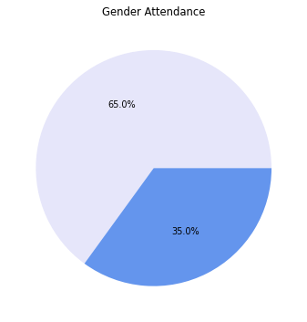

```python
gender_counts = df['Gender'].value_counts()
colors = ['#E6E6FA', '#6495ED']
fig, ax = plt.subplots(figsize=(6, 6), dpi=70)
plt.pie(gender_counts, autopct='%3.1f%%',colors=colors)
plt.title('Gender Attendance')
plt.show()
```

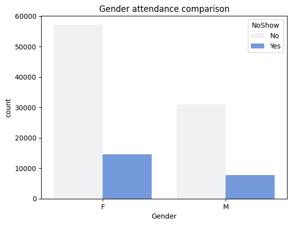

```python
plot = sns.countplot(x=df['Gender'], hue=df['NoShow'], data=df,color='#6495ED')
plot.set_title("Gender attendance comparison")
x_ticks_labels = ['F', 'M']
plot.set_xticklabels(x_ticks_labels)

plt.show()
```

In this code, a countplot visualization was created using the Seaborn library to compare attendance based on gender.

```python
pd.crosstab(index=df['Gender'], columns=df['NoShow'], normalize='index')
```

| NoShow Gender | No | Yes |
| --- | --- | --- |
| F | 0.796851 | 0.203149 |
| M | 0.800321 | 0.199679 |

Considering the significant difference in sample sizes between the genders (71,840 females vs. 38,687 males), it's important to account for this imbalance. To obtain a more accurate comparison, the pd.crosstab() function with normalize='index' was used. This normalized the values within each row, revealing that both males and females showed similar commitment to attending appointments, with attendance ratios being very close. Thus, gender is not considered a significant correlation factor in this analysis.

# Which age group has a higher number of no-shows for appointments?

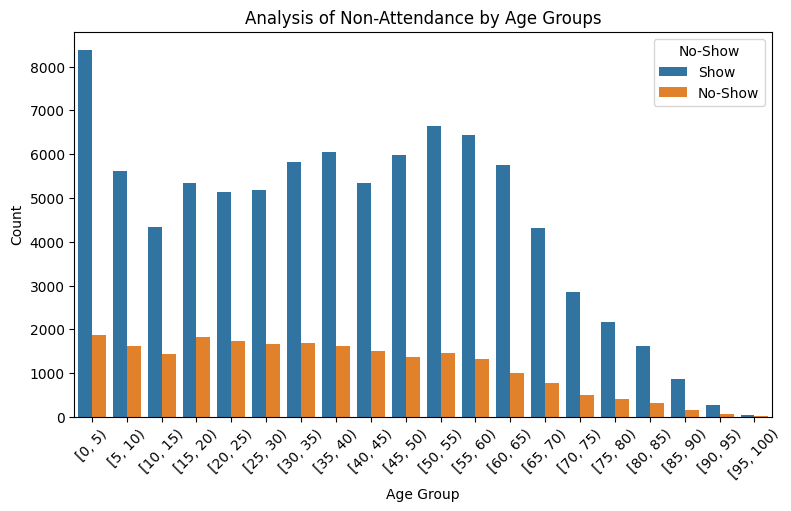

```python
df['Age_Group'] = pd.cut(df['Age'], bins=range(0, 101, 5), right=False)

plt.figure(figsize=(9, 5))
sns.countplot(x='Age_Group', hue='NoShow', data=df)
plt.xlabel('Age Group')
plt.ylabel('Count')
plt.title('Analysis of Non-Attendance by Age Groups')
plt.legend(title='No-Show', labels=['Show', 'No-Show'])
plt.xticks(rotation=45)
plt.show()
```

Based on the chart illustrating the number of "show" and "no show" appointments for each age group, grouped into five-year intervals, the analysis reveals the following insights:

1-Early Childhood Attendance: The age group of 0-5 years demonstrates the highest attendance, suggesting that parents or guardians prioritize healthcare appointments for young children.

# Is there a correlation between having a handicap and not showing up for appointments?

```python
 df['Handicap'].value_counts()
```

```
0    108286
1      2241
Name: Handicap, dtype: int64
```

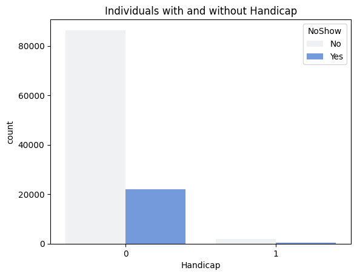

```python
plot = sns.countplot(x=df['Handicap'], hue=df['NoShow'], data=df,color='#6495ED')
plot.set_title("Individuals with and without Handicap")
x_ticks_labels = ['0', '1']
plot.set_xticklabels(x_ticks_labels)

plt.show()
```

The data does not provide strong evidence to support a significant relationship or correlation between the presence of a handicap and attendance at appointments.

# Does receiving SMS increase the chances of show-up?

```python
 df['SMS_received'].value_counts()
```

```
0    75044
1    35482
Name: SMS_received, dtype: int64
```

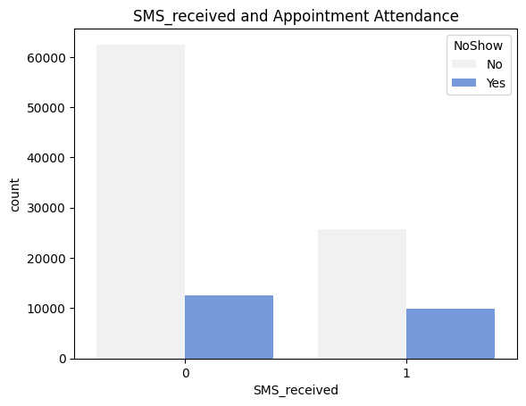

```python
plot = sns.countplot(x=df['SMS_received'], hue=df['NoShow'], data=df,color='#6495ED')
plot.set_title("SMS_received and Appointment Attendance")
x_ticks_labels = ['0', '1']
plot.set_xticklabels(x_ticks_labels)

plt.show()
```

The chart illustrates the attendance percentages for individuals who received a message (labeled as 1) and those who did not receive a message (labeled as 0). Surprisingly, the data reveals that individuals who did not receive a message had a higher attendance rate compared to those who received a message.

## Submitting your Project

```python
# Running this cell will execute a bash command to convert this notebook to an .html file
!python -m nbconvert --to html Investigate_a_Dataset.ipynb
```